```python
import pandas as pd
import matplotlib.pyplot as plt
import numpy as np
import nltk
import geopandas as gpd
from shapely.geometry import Point, Polygon
from descartes import PolygonPatch
```

```python
conflicts = pd.read_csv("Datasets/WCC_PacificInstitute_926conflicts.csv")
c = conflicts
```

# Understanding the Data

```python
conflicts.shape
```

```
(926, 13)
```

```python
conflicts.head(1)
```

|  | Start | End | Date text | Date (for research purposes only) | Region | Country | Lat | Long | Basis | Headline | Description | Sources | Unnamed: 12 |
| --- | --- | --- | --- | --- | --- | --- | --- | --- | --- | --- | --- | --- | --- |
| 0 | 1998 | 1998 | 1998 | NaN | Northern Africa | Algeria | 34.3863 | 4.95587 | Casualty | Attack on water system in Algeria | A bomb placed by a group suspected to be affil... | A.B. 1998; National Consortium for the Study o... | NaN |

```python
conflicts.dtypes
```

```
Start                                  int64
End                                    int64
Date text                             object
Date (for research purposes only)     object
Region                                object
Country                               object
Lat                                  float64
Long                                  object
Basis                                 object
Headline                              object
Description                           object
Sources                               object
Unnamed: 12                          float64
dtype: object
```

# Clean Up Data

## Drop unneccessary columns

Analysis will **focus** on event `date`, location (`region`, `country`, `lat`, and `long`) and basic details (`cause`, `headline`, `description`). We will **drop** columns pertaining to research which include `unnamed 12`and `data (for research purposes only)`.

*We will keep the `sources` column even though it will not be used in analysis for refrence purposes.*

```python
conflicts = conflicts.drop(["Date (for research purposes only)","Unnamed: 12", "Date text"], axis=1)
```

```python
conflicts = conflicts[conflicts.Start>=0 ]
```

## Identify and fix null values

```python
conflicts.isna().any()
```

```
Start          False
End            False
Region         False
Country        False
Lat            False
Long           False
Basis          False
Headline        True
Description    False
Sources        False
dtype: bool
```

There seems to be one or more headlines that are not listed. Let's invesitgate further.

```python
conflicts[conflicts.isna().any(axis=1)]
```

|  | Start | End | Region | Country | Lat | Long | Basis | Headline | Description | Sources |
| --- | --- | --- | --- | --- | --- | --- | --- | --- | --- | --- |
| 863 | 2002 | 2002 | Sub-Saharan Africa | South Africa | -26.55 | 29.1667 | Trigger | NaN | Hundreds of residents and municipal union memb... | Raleigh et al N.D. I.D. 4993409 |

There is only one headline that is missing. To fix this, we will extrpolate relevant details from the description and include them in the headline.

```python
conflicts.loc[863, "Description"]
```

```
'Hundreds of residents and municipal union members protest the lack of free water in their town in South Africa.'
```

```python
conflicts.loc[863, "Headline"] = "Residents protest lack of free water"
```

```python
conflicts['Duration'] = conflicts.End - conflicts.Start
long = conflicts[conflicts.Duration>0]
long.shape
```

```
(57, 11)
```

```python
long.sort_values("Duration").head()
```

|  | Start | End | Region | Country | Lat | Long | Basis | Headline | Description | Sources | Duration |
| --- | --- | --- | --- | --- | --- | --- | --- | --- | --- | --- | --- |
| 17 | 2012 | 2013 | Sub-Saharan Africa | Kenya | -1.50000 | 40 | Trigger | Ethnic conflict in Kenya fueled by water | Extensive violence over water is reported in K... | Agence France-Presse (AFP) 2012a; Al Jazeera 2012 | 1 |
| 710 | 1963 | 1964 | Sub-Saharan Africa | Ethiopia, Somalia | 7.27056 | 44.2772 | Trigger | Ethiopia and Somali nomads fight for desert water | Creation of boundaries in 1948 leaves Somali n... | Wolf 1997 | 1 |
| 708 | 1965 | 1966 | Western Asia | Israel, Jordan, Syria | 33.18670 | 35.6192 | Trigger | Israel attacks over Arab water plan | Fire is exchanged over "all-Arab" plan to dive... | Wolf 1995; Wolf 1997 | 1 |
| 692 | 1908 | 1909 | North America | United States | 36.36920 | -89.4054 | Trigger | Violence over fishing in Tennessee | Violence, including a murder, directed against... | Vanderwood 1969 | 1 |
| 661 | 1981 | 1982 | Sub-Saharan Africa | Angola, Namibia | -12.54650 | 17.9324 | Casualty | Namibia targets Angola pipeline | Water infrastructure, including dams and the m... | Turton 2005 | 1 |

```python
#checkpoint
#conflicts.shape
```

## Seperate Columns with Multiple Values by Rows

Because there are conflicts with multiple countries listed in the `Country` column, we will first split entries with multiple countries into multiple rows with each row having corresponding with only one country.

- for example:
  - Before:

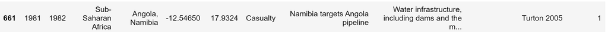

  - After:

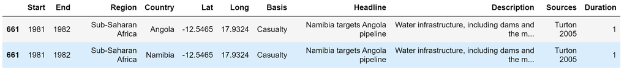

```python
conflicts_lists = conflicts['Country'].str.split(", ")
```

```python
conflicts['Country'] = conflicts_lists
conflict = conflicts.explode('Country')
```

# Top values

We will know take a look at the distribution of conflicts based on different categories.

## Countries

```python
top_countries = conflict.Country.value_counts().to_frame()
```

```python
top_countries = top_countries.rename(columns = {"Country":"Sum"})
```

```python
#arr = np.array(top_countries.index)
#arr
top_countries["Percent"] = top_countries.Sum.transform(lambda x: x / x.sum())

top_countries["Percent"] = top_countries["Percent"].astype(float).map("{:.2%}".format)
top_countries.head()
```

|  | Sum | Percent |
| --- | --- | --- |
| Yemen | 136 | 13.95% |
| Iraq | 75 | 7.69% |
| United States | 47 | 4.82% |
| India | 46 | 4.72% |
| Pakistan | 36 | 3.69% |

## Years

```python
top_years = conflict.Start.value_counts().to_frame()

top_years = top_years.rename(columns = {"Start":"Sum"})
top_years["Percent"] = top_years.Sum.transform(lambda x: x / x.sum())

top_years["Percent"] = top_years["Percent"].astype(float).map("{:.2%}".format)
top_years.head()
```

|  | Sum | Percent |
| --- | --- | --- |
| 2017 | 87 | 8.92% |
| 2018 | 72 | 7.38% |
| 2016 | 62 | 6.36% |
| 2012 | 57 | 5.85% |
| 2015 | 54 | 5.54% |

## Regions

```python
top_regions = conflict.Region.value_counts().to_frame()

top_regions = top_regions.rename(columns = {"Region":"Sum"})
top_regions["Percent"] = top_regions.Sum.transform(lambda x: x / x.sum())

top_regions["Percent"] = top_regions["Percent"].astype(float).map("{:.2%}".format)
top_regions.head()
```

|  | Sum | Percent |
| --- | --- | --- |
| Western Asia | 311 | 31.90% |
| Sub-Saharan Africa | 187 | 19.18% |
| Southern Asia | 129 | 13.23% |
| Latin America and the Caribbean | 69 | 7.08% |
| Northern Africa | 61 | 6.26% |

## Basis of conflict

```python
top_basis = pd.Series(conflict.Basis.str.split(', ').sum()).value_counts()
```

```python
top_basis.Trigger = top_basis.Trigger + top_basis.Tigger + top_basis.Triggr
top_basis = top_basis.drop(["Triggr", "Tigger"])
```

```python
top_basis = top_basis.to_frame()
```

```python
top_basis = top_basis.rename(columns = {0:"Sum"})
top_basis["Percent"] = top_basis["Sum"].transform(lambda x: x / x.sum())

top_basis["Percent"] = top_basis["Percent"].astype(float).map("{:.2%}".format)
top_basis.head()
```

|  | Sum | Percent |
| --- | --- | --- |
| Casualty | 526 | 49.86% |
| Trigger | 351 | 33.27% |
| Weapon | 178 | 16.87% |

## Issues fought over

### Text Mining

Let's take a look at what issues have influenced conflicts through the course of time. To do this, we will use the `Description` column from `conflicts` and identify the most frequent keywords by `Start` year.

First, we will go through and tokenized words for each entry within `Description` and remove any commonly used words (i.e. a, an, the).

```python
from nltk.corpus import stopwords
from nltk import word_tokenize
import string
stoplist = stopwords.words('english') + list(string.punctuation)
stoplist = set(stoplist)
```

```python
def preprocess(text):
    return [word for word in word_tokenize(text) if word.lower() not in stoplist and not word.isdigit()]
```

```python
conflict['Filtered_Description'] = conflict['Description'].apply(preprocess)
conflict['Word_Frq'] = conflict['Filtered_Description']
```

Now, we will count the frequency of each word in this column by year and export it to `arr`.

```python
def unnesting(df, explode):
    idx=df.index.repeat(df[explode[0]].str.len())
    df1=pd.concat([pd.DataFrame({x:np.concatenate(df[x].values)} )for x in explode],axis=1)
    df1.index=idx
    return df1.join(df.drop(explode,1),how='left')
```

```python
arr = unnesting(conflict,['Word_Frq']).groupby(['Start','Word_Frq']).size().sort_values().reset_index()
arr = arr.rename(columns = {0:"Freq", "Word_Frq": "Word"})
```

We can now take `arr` and group it further to see the word with the maximum frequency in each year.

```python
maximum = arr.loc[arr.groupby("Start")["Freq"].idxmax()]
maximum.head()
```

|  | Start | Word | Freq |
| --- | --- | --- | --- |
| 9962 | 30 | Pilate | 2 |
| 9963 | 537 | AD | 2 |
| 9920 | 1187 | water | 2 |
| 9911 | 1260 | feeding | 2 |
| 9907 | 1503 | Pisa | 2 |

```python
maximum.loc[maximum.Start>1919].Word.value_counts().index[:5]
```

```
Index(['water', 'Israel', 'Korea', 'River', 'Lake'], dtype='object')
```

In the past 100 years, **water** appears to have the most frequent occurrence within conflicts, followed by **Israel**.

# Case Country: Yemen

```python
yemen = conflict.loc[conflict.Country == "Yemen"]
```

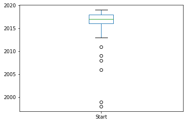

```python
yemen.Start.plot(kind="box")
```

Although Yemen had the most reported conflicts, it appears many of them have occured within the span of three years (2016-2018). This reflects the civil war that has been going in Yemen since 2014.

## Word Frequency

Using the same process that we used to identify the most frequent words in the `Description` column by year, we will identify the most frequent words that appeared in conflicts that involve **Yemen**.

```python
y = unnesting(conflict,['Word_Frq']).groupby(['Start','Country','Word_Frq']).size().sort_values().reset_index()
y = y.rename(columns = {0:"Freq", "Word_Frq": "Word"})
```

```python
y = y.loc[y.Country == "Yemen"]
y.loc[y.groupby("Start")["Freq"].idxmax()].Word.value_counts().index[:5]
```

```
Index(['water', 'Aden', 'two', 'reports', 'Abyan'], dtype='object')
```

Not surprisingly, the most common word used as description all conflicts in the past 100 years (*water*) is the same word that appears most frequently for conflicts involoving Yemen.

```python
y.loc[(y.Word == "water") & (y.Country == "Yemen")]['Freq'].sum()
```

```
133
```

In total, the word *water* was used 133 times to describe a conflict involoving Yemen.

## Other countries involoved

```python
#c is a copy of the orginal unformatted dataframe from the csv file
c[c['Country'].str.contains("Yemen")].loc[c.Country != "Yemen"]
```

|  | Start | End | Date text | Date (for research purposes only) | Region | Country | Lat | Long | Basis | Headline | Description | Sources | Unnamed: 12 |
| --- | --- | --- | --- | --- | --- | --- | --- | --- | --- | --- | --- | --- | --- |

It seems that all reported conflicts in this dataset involving Yemen have only involved Yemen. No other countries have been reported to be directly part of conflict.

## Geographical Distribution of Conflicts

Using GeoPandas and a map of Yemen's governorates, we will plot the distribution of the conflicts based on location.

```python
loct = yemen
```

```python
loct = loct.rename(columns={'Lat':'Latitude', "Long":"Longitude"})

loct['Longitude'] = loct['Longitude'].astype(float)
loct['Latitude'] = loct['Latitude'].astype(float)
```

```python
#specify coordinate system
crs = {'init':'epsg:4326'}

#creat list of longitude and latitude that been converted to Points
geometry = [Point(xy) for xy in zip(loct.Longitude, loct.Latitude)]

#create GeoDataFrame using orignal dataFrame (loct), Points and coordinate system
geo_df = gpd.GeoDataFrame(loct, crs=crs, geometry=geometry)
```

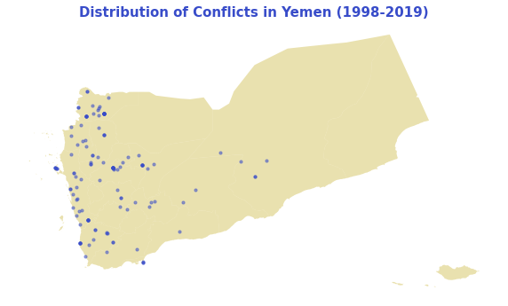

```python
#import map
smap = gpd.read_file('Datasets/Map/Yemen/Governorate.shp')

#set figure size
fig, ax = plt.subplots(figsize=(10,10))

# add map to axes
smap.plot(ax=ax, alpha=0.4,color='#C9B438')

# add geodataframe to axes
geo_df.plot(color="#384CC9", ax=ax,alpha=.5, markersize=10)

# add title to graph
plt.title("Distribution of Conflicts in Yemen (1998-2019)", color="#384CC9",fontsize=15,fontweight='bold')

#hide box surronding graph
plt.box(False)

#turn off axes
plt.axis('off')

# show map
plt.show()
```

Many of the conflicts in Yemen are centered around the front lines of the civil war. Undoubtedly civil war in Yemen has wreaked havoc on the country. To find out more about the war as well as the impact it has on the country, this report is a great resource: https://www.ecfr.eu/mena/yemen